# DATA SCIENCE PROJECT

# Distribution Plot of the Continuous Variable

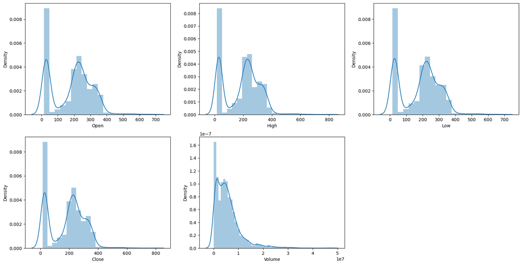

```python
features = ['Open', 'High', 'Low', 'Close', 'Volume']

plt.subplots(figsize=(20,10))

for i, col in enumerate(features):
    plt.subplot(2,3,i+1)
    sb.distplot(df[col])
plt.show()
```

# Box Plot of the Continuous Variable

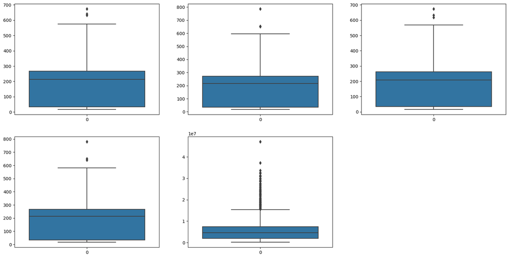

```python
plt.subplots(figsize=(20,10))
for i, col in enumerate(features):
    plt.subplot(2,3,i+1)
    sb.boxplot(df[col])
plt.show()
```

# Feature Engineering

Feature Engineering helps to derive some valuable features from the existing ones. These extra features sometimes help in increasing the performance of the model significantly and certainly help to gain deeper insights into the data.

```python
df['Date'] = pd.to_datetime(df['Date'])
df['day'] = df['Date'].dt.day
df['month'] = df['Date'].dt.month
df['year'] = df['Date'].dt.year

df.head()
```

|  | Date | Open | High | Low | Close | Volume | day | month | year |
| --- | --- | --- | --- | --- | --- | --- | --- | --- | --- |
| 0 | 2010-06-29 | 19.000000 | 25.00 | 17.540001 | 23.889999 | 18766300 | 29 | 6 | 2010 |
| 1 | 2010-06-30 | 25.790001 | 30.42 | 23.299999 | 23.830000 | 17187100 | 30 | 6 | 2010 |
| 2 | 2010-07-01 | 25.000000 | 25.92 | 20.270000 | 21.959999 | 8218800 | 1 | 7 | 2010 |
| 3 | 2010-07-02 | 23.000000 | 23.10 | 18.709999 | 19.200001 | 5139800 | 2 | 7 | 2010 |
| 4 | 2010-07-06 | 20.000000 | 20.00 | 15.830000 | 16.110001 | 6866900 | 6 | 7 | 2010 |

```python
df['is_quarter_end'] = np.where(df['month']%3==0,1,0)
df.head()
```

|  | Date | Open | High | Low | Close | Volume | day | month | year | is_quarter_end |
| --- | --- | --- | --- | --- | --- | --- | --- | --- | --- | --- |
| 0 | 2010-06-29 | 19.000000 | 25.00 | 17.540001 | 23.889999 | 18766300 | 29 | 6 | 2010 | 1 |
| 1 | 2010-06-30 | 25.790001 | 30.42 | 23.299999 | 23.830000 | 17187100 | 30 | 6 | 2010 | 1 |
| 2 | 2010-07-01 | 25.000000 | 25.92 | 20.270000 | 21.959999 | 8218800 | 1 | 7 | 2010 | 0 |
| 3 | 2010-07-02 | 23.000000 | 23.10 | 18.709999 | 19.200001 | 5139800 | 2 | 7 | 2010 | 0 |
| 4 | 2010-07-06 | 20.000000 | 20.00 | 15.830000 | 16.110001 | 6866900 | 6 | 7 | 2010 | 0 |

# bar graph

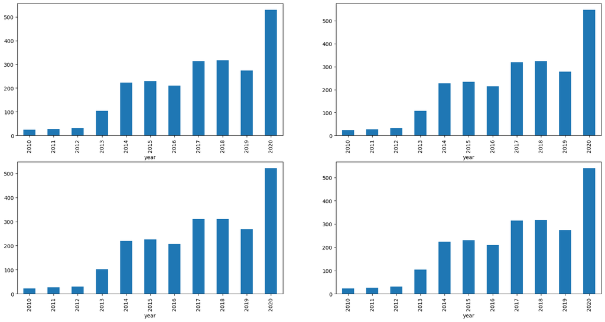

```python
data_grouped = df.groupby('year').mean()
plt.subplots(figsize=(20,10))

for i, col in enumerate(['Open', 'High', 'Low', 'Close']):
    plt.subplot(2,2,i+1)
    data_grouped[col].plot.bar()
plt.show()
```

```python
df.groupby('is_quarter_end').mean()
```

| is_quarter_end | Open | High | Low | Close | Volume | day | month | year |
| --- | --- | --- | --- | --- | --- | --- | --- | --- |
| 0 | 185.875081 | 189.254226 | 182.449499 | 186.085081 | 5.767062e+06 | 15.710396 | 6.173886 | 2014.816213 |
| 1 | 187.071200 | 190.232700 | 183.860262 | 187.047163 | 5.180154e+06 | 15.825000 | 7.597500 | 2014.697500 |

```python
df['open-close'] = df['Open'] - df['Close']
df['low-high'] = df['Low'] - df['High']
df['target'] = np.where(df['Close'].shift(-1) > df['Close'], 1, 0)
```

# pie chart.

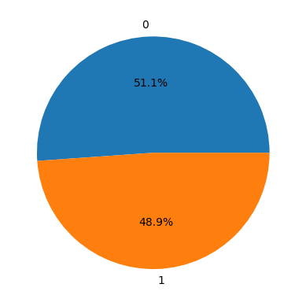

```python
plt.pie(df['target'].value_counts().values,
		labels=[0, 1], autopct='%1.1f%%')
plt.show()
```

# Heatmap of the correlation between the features

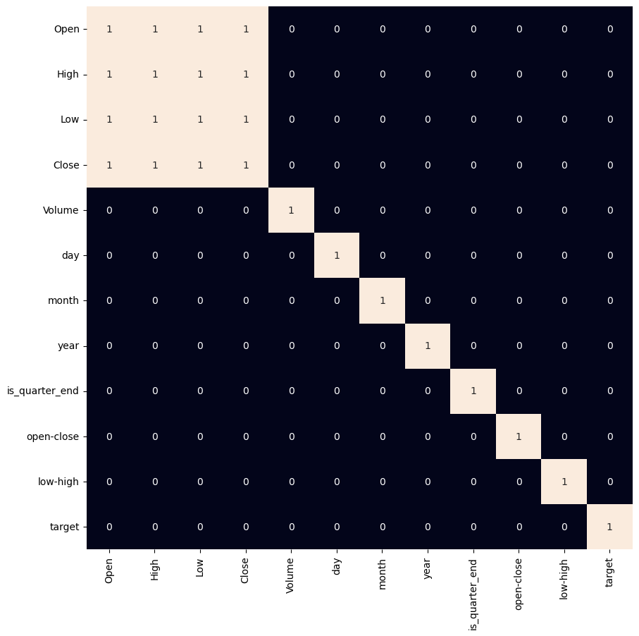

```python
plt.figure(figsize=(10, 10))

# As our concern is with the highly
# correlated features only so, we will visualize
# our heatmap as per that criteria only.
sb.heatmap(df.corr() > 0.9, annot=True, cbar=False)
plt.show()
```

# Data Splitting and Normalization

```python
features = df[['open-close', 'low-high', 'is_quarter_end']]
target = df['target']

scaler = StandardScaler()
features = scaler.fit_transform(features)

X_train, X_valid, Y_train, Y_valid = train_test_split(
	features, target, test_size=0.1, random_state=2022)
print(X_train.shape, X_valid.shape)
```

```
(2174, 3) (242, 3)
```

# Model Development and Evaluation

```python
models = [LogisticRegression(), SVC(
kernel='poly', probability=True), XGBClassifier()]

for i in range(3):
 models[i].fit(X_train, Y_train)

print(f'{models[i]} : ')
print('Training Accuracy : ', metrics.roc_auc_score(
	Y_train, models[i].predict_proba(X_train)[:,1]))
print('Validation Accuracy : ', metrics.roc_auc_score(
	Y_valid, models[i].predict_proba(X_valid)[:,1]))
print()
```

```
XGBClassifier(base_score=None, booster=None, callbacks=None,
              colsample_bylevel=None, colsample_bynode=None,
              colsample_bytree=None, early_stopping_rounds=None,
              enable_categorical=False, eval_metric=None, feature_types=None,
              gamma=None, gpu_id=None, grow_policy=None, importance_type=None,
              interaction_constraints=None, learning_rate=None, max_bin=None,
              max_cat_threshold=None, max_cat_to_onehot=None,
              max_delta_step=None, max_depth=None, max_leaves=None,
              min_child_weight=None, missing=nan, monotone_constraints=None,
              n_estimators=100, n_jobs=None, num_parallel_tree=None,
              predictor=None, random_state=None, ...) :
Training Accuracy :  0.968013309795654
Validation Accuracy :  0.41772714833059665
```

# confusion matrix

```python
from sklearn.metrics import confusion_matrix
import matplotlib.pyplot as plt
import seaborn as sns
```

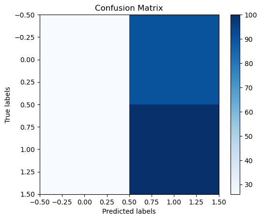

```python
from sklearn.metrics import confusion_matrix
import matplotlib.pyplot as plt

# Calculate the confusion matrix
confusion_mat = confusion_matrix(Y_valid, models[0].predict(X_valid))

# Plot the confusion matrix using Matplotlib
plt.imshow(confusion_mat, interpolation='nearest', cmap='Blues')
plt.title('Confusion Matrix')
plt.colorbar()
plt.xlabel('Predicted labels')
plt.ylabel('True labels')
plt.show()
```

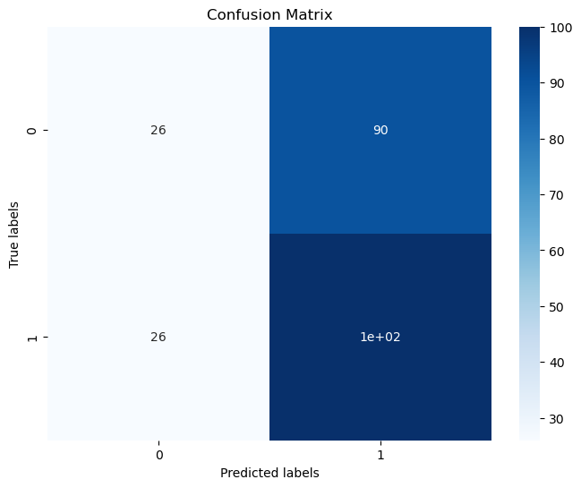

```python
from sklearn.metrics import confusion_matrix
import matplotlib.pyplot as plt
import seaborn as sns

# Calculate the confusion matrix
confusion_mat = confusion_matrix(Y_valid, models[0].predict(X_valid))

# Plot the confusion matrix using a heatmap
plt.figure(figsize=(8, 6))
sns.heatmap(confusion_mat, annot=True, cmap='Blues')
plt.xlabel('Predicted labels')
plt.ylabel('True labels')
plt.title('Confusion Matrix')
plt.show()
```

# Conclusion:

the accuracy achieved by the state-of-the-art ML model is no better than simply guessing with a probability of 50%. Possible reasons for this may be the lack of data or using a very simple model to perform such a complex task as Stock Market prediction.